# Single cell RNA-seq data visualization

## Practice heatmap

Re-run heatmap part of the workshop if needed. This is copied exactly from the workshop.

```r
#Extract scaled expression data
pbmc_counts_log <- as.data.frame(GetAssayData(
  object = pbmc,
  slot = "scale.data"))

#Order cells by clusters. Remember that we originally
# got these data from as.data.frame(pbmc$seurat_clusters)
cell_order <- cell_clusters %>%
  arrange(`pbmc$seurat_clusters`)
```

Create “top 3” data for second exercise. Again this is copied from the workshop

```r
top3 <- pbmc_markers %>%
  group_by(cluster) %>%
  top_n(n = 3, wt = avg_log2FC)

pbmc_counts_log_top3 <- pbmc_counts_log %>%
  #Filter top genes
  rownames_to_column("gene") %>%
  filter(gene %in% top3$gene) %>%
  #Remove outliers
  mutate_if(is.numeric, ~ifelse(. > 2.5, 2.5, .)) %>%
  #Reorder cells
  select(gene, all_of(rownames(cell_order))) %>%
  #Reorder genes
  mutate(gene = factor(gene, levels = unique(top3$gene))) %>%
  arrange(gene) %>%
  #Convert to matrix
  column_to_rownames("gene") %>%
  as.matrix()
```

#### Create a heatmap of the top 20 marker genes in clusters. Which clusters better resolve with de novo clustering?

This time, let’s select “top” as the most significant, instead of the largest fold change. We’ll use `slice_min( )` for this.

Format data.

```r
top20 <- pbmc_markers %>%
  group_by(cluster) %>%
  slice_min(n = 20, order_by = p_val_adj)

pbmc_counts_log_top20 <- pbmc_counts_log %>%
  #Filter top genes
  rownames_to_column("gene") %>%
  filter(gene %in% top20$gene) %>%
  #Remove outliers
  mutate_if(is.numeric, ~ifelse(. > 2.5, 2.5, .)) %>%
  #Reorder cells
  select(gene, all_of(rownames(cell_order))) %>%
  #Reorder genes
  mutate(gene = factor(gene, levels = unique(top20$gene))) %>%
  arrange(gene) %>%
  #Convert to matrix
  column_to_rownames("gene") %>%
  as.matrix()
```

```
## The automatically generated colors map from the 1^st and 99^th of the
## values in the matrix. There are outliers in the matrix whose patterns
## might be hidden by this color mapping. You can manually set the color
## to `col` argument.
##
## Use `suppressMessages()` to turn off this message.
```

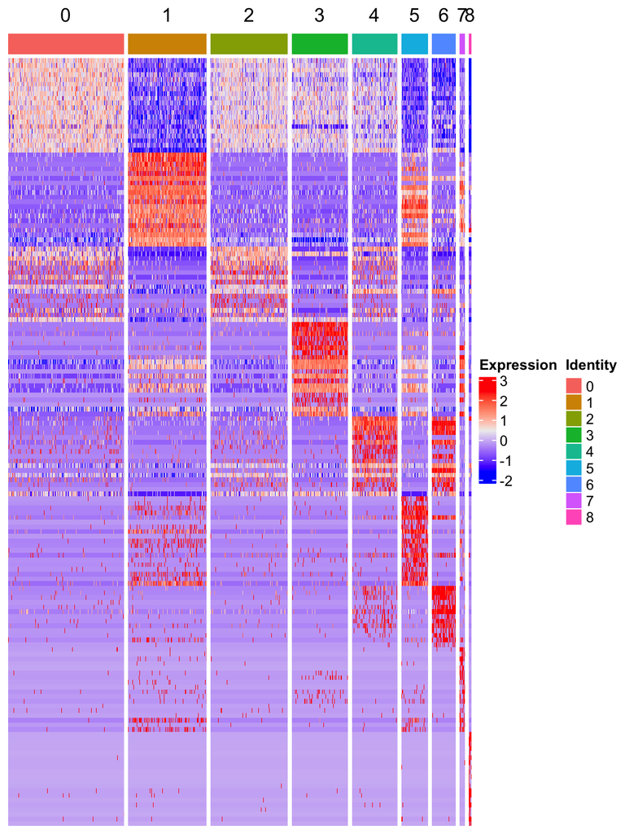

```r
#Format cluster annotation
hm_clusters <- cell_order$`pbmc$seurat_clusters`
names(hm_clusters) <- rownames(cell_order)

#Make cluster colors the same as ggplot default
hm_colors <- scales::hue_pal()(9)
names(hm_colors) <- as.character(c(0:8))

#Format ComplexHeatmap annotation
#This is the not great syntax that the reference can help with
hm_anno <- HeatmapAnnotation(
  Identity = hm_clusters,
  col = list(Identity = hm_colors),
  show_annotation_name = FALSE)

#Make heatmap
Heatmap(pbmc_counts_log_top20, use_raster = FALSE,
        cluster_rows = FALSE, cluster_columns = FALSE,
        name = "Expression",
        column_split = hm_clusters,
        show_column_names = FALSE, #remove cell (column) labels
        show_row_names = FALSE, #remove gene (row) labels
        top_annotation = hm_anno) #add cluster annotation
```

And with clustering, where we see that clusters 1 and 3 are nicely resolved. In contrast, notice how clusters 0 and 2 are heavily mixed. If we knew the cell-type identities of these clusters, these results could lead to interesting findings such as showing that gene expression is more or less similar in different cell types.

```
## The automatically generated colors map from the 1^st and 99^th of the
## values in the matrix. There are outliers in the matrix whose patterns
## might be hidden by this color mapping. You can manually set the color
## to `col` argument.
##
## Use `suppressMessages()` to turn off this message.
```

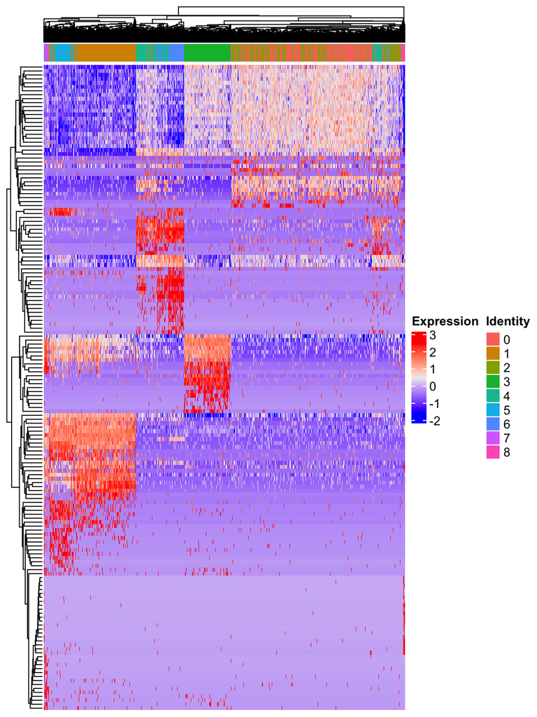

```r
Heatmap(pbmc_counts_log_top20, use_raster = FALSE,
        cluster_rows = TRUE, cluster_columns = TRUE,
        name = "Expression",
        show_column_names = FALSE, #remove cell (column) labels
        show_row_names = FALSE, #remove gene (row) labels
        top_annotation = hm_anno) #add cluster annotation
```

#### Create a heatmap of the top 3 marker genes in only clusters 0 and 1.

First, list all the cells in these two clusters.

```r
cells_c0_1 <- cell_clusters %>%
  rownames_to_column("cell") %>%
  filter(`pbmc$seurat_clusters` %in% c(0,1)) %>%
  pull(cell)
```

Then filter the expression data to these cells.

```r
pbmc_counts_log_top3_c01 <- as.data.frame(pbmc_counts_log_top3) %>%
  rownames_to_column() %>%
  # move cells (which are indiv columns) into 1 column so we can filter it
  pivot_longer(-rowname, names_to = "cell") %>%
  # filer cells
  filter(cell %in% cells_c0_1) %>%
  #Put back to wide matrix for heatmap
  pivot_wider(names_from = "cell") %>%
  column_to_rownames() %>%
  as.matrix()

#also filter the cluster splitting vector
hm_clusters_01 <- hm_clusters[names(hm_clusters) %in% cells_c0_1]

#And the annotation object
hm_anno_01 <- HeatmapAnnotation(
  Identity = hm_clusters_01,
  col = list(Identity = hm_colors[1:2]),
  show_annotation_name = FALSE)
```

Plot! Let’s cluster the genes (rows) to highlight similarities between the two clusters.

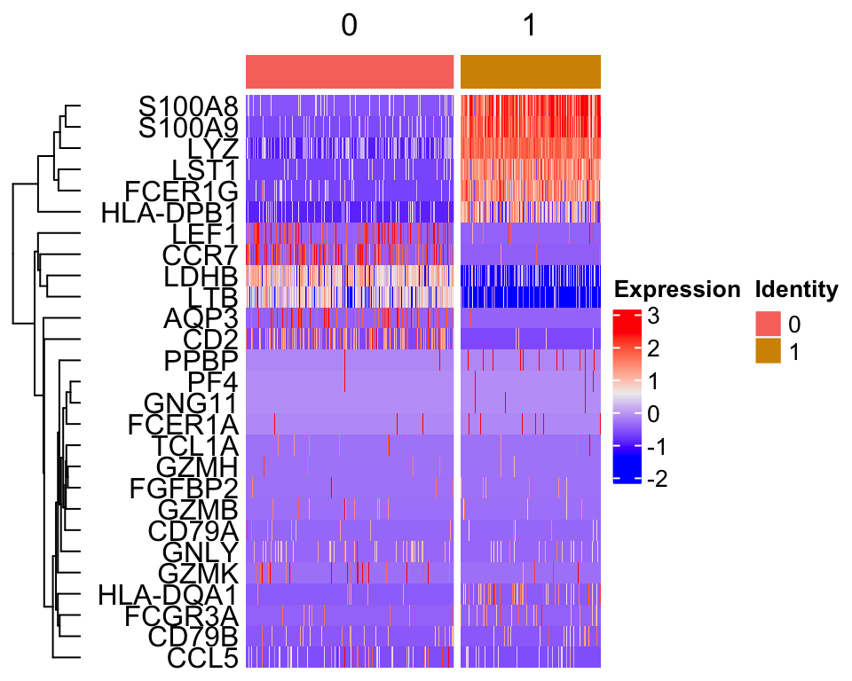

```r
Heatmap(pbmc_counts_log_top3_c01, use_raster = FALSE,
        cluster_rows = TRUE, cluster_columns = FALSE, #Turn clustering on
        name = "Expression",
        column_split = hm_clusters_01,
        show_column_names = FALSE, #remove cell (column) labels
        row_names_side = "left", #move gene (row) labels
        top_annotation = hm_anno_01 #add cluster annotation
        )
```

# *Navigation*

- [Workshop index](https://bigslu.github.io/workshops/)